# BIOS 667 - Lecture 7: Modeling the Covariance (Ch. 7)

## Diagnostic: Empirical Semivariogram

**Beyond FLW (instructor extension)**

The semivariogram is a Diggle-style tool (cf. Diggle, Heagerty, Liang and Zeger, *Analysis of Longitudinal Data*), not part of FLW Ch. 7. Shown here as a useful visual check on how residual correlation decays with time separation.

A **variogram** plots residual variance versus time separation.

| Pattern | Interpretation |
| --- | --- |
| Flat variogram | Compound Symmetry may be reasonable |
| Increasing variogram | Correlation decays with time (AR(1), Exponential) |

## Semivariogram: Visualization

```r
library(nlme)

# Calculate empirical variogram from independence model residuals
vario_gls <- Variogram(gls_ind, form = ~ time_num)

plot(vario_gls, main = "Empirical Semivariogram of Residuals",
     xlab = "Time Lag (Weeks)", ylab = "Semivariance")
```

## Semivariogram: Visualization

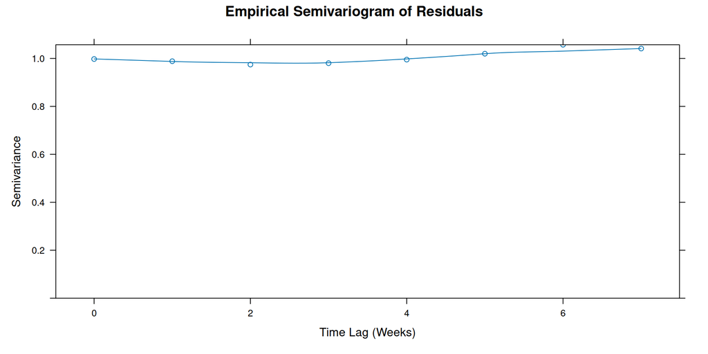

## FLW Ch. 7 Diagnostic: UN vs Pattern-Implied $\Sigma$

The diagnostic FLW Ch. 7 actually uses: fit the **unstructured** correlation matrix, then compare it to the correlation matrix **implied** by a pattern (e.g. AR(1) or CS). A REML likelihood-ratio test of the pattern against UN formalizes the comparison.

In FLW’s exercise-therapy example, the AR-vs-UN REML-LRT gives $G^2 = 23.8$ on 13 df, $p < 0.05$ (FLW p. 182), so the AR pattern does **not** provide an adequate fit relative to UN (AR is rejected). The exponential model (also 2 parameters) is the one FLW prefers: it has the lowest AIC and, unlike AR, is not rejected against UN at 0.05 ($G^2 = 21.2$ on 13 df, $p \approx 0.07$).

## UN vs Pattern-Implied: Estimated Matrices

```r
# Fit the unstructured correlation model on the simulated AR(1) data
gls_un_sim <- gls(y ~ group * time_f, data = sim_long,
                  correlation = corSymm(form = ~ time_idx | id),
                  weights = varIdent(form = ~ 1 | time_f),
                  method = "REML")

# Estimated UN correlation matrix (the "data-driven" target)
cor_un <- corMatrix(gls_un_sim$modelStruct$corStruct)[[1]]

# AR(1)-implied correlation matrix: rho^|j-k|
rho_hat <- as.numeric(coef(gls_ar1$modelStruct$corStruct, unconstrained = FALSE))
lags    <- abs(outer(seq_len(m), seq_len(m), "-"))
cor_ar1 <- rho_hat ^ lags

round(cor_un, 2)    # unstructured estimate
```

## UN vs Pattern-Implied: Estimated Matrices

```
     [,1] [,2] [,3] [,4] [,5] [,6] [,7] [,8]
[1,] 1.00 0.81 0.65 0.49 0.37 0.26 0.20 0.15
[2,] 0.81 1.00 0.80 0.63 0.49 0.37 0.28 0.19
[3,] 0.65 0.80 1.00 0.78 0.63 0.46 0.36 0.27
[4,] 0.49 0.63 0.78 1.00 0.80 0.61 0.48 0.36
[5,] 0.37 0.49 0.63 0.80 1.00 0.76 0.63 0.49
[6,] 0.26 0.37 0.46 0.61 0.76 1.00 0.83 0.65
[7,] 0.20 0.28 0.36 0.48 0.63 0.83 1.00 0.80
[8,] 0.15 0.19 0.27 0.36 0.49 0.65 0.80 1.00
```

```r
round(cor_ar1, 2)   # AR(1) pattern-implied
```

```
     [,1] [,2] [,3] [,4] [,5] [,6] [,7] [,8]
[1,] 1.00 0.80 0.64 0.52 0.41 0.33 0.27 0.21
[2,] 0.80 1.00 0.80 0.64 0.52 0.41 0.33 0.27
[3,] 0.64 0.80 1.00 0.80 0.64 0.52 0.41 0.33
[4,] 0.52 0.64 0.80 1.00 0.80 0.64 0.52 0.41
[5,] 0.41 0.52 0.64 0.80 1.00 0.80 0.64 0.52
[6,] 0.33 0.41 0.52 0.64 0.80 1.00 0.80 0.64
[7,] 0.27 0.33 0.41 0.52 0.64 0.80 1.00 0.80
[8,] 0.21 0.27 0.33 0.41 0.52 0.64 0.80 1.00
```

## UN vs Pattern-Implied: REML-LRT

```r
# REML-LRT: AR(1) (reduced) nested in UN (full).
# Both share the same maximal mean model, so REML logLik is comparable.
G2 <- 2 * (as.numeric(logLik(gls_un_sim)) - as.numeric(logLik(gls_ar1)))
df <- attr(logLik(gls_un_sim), "df") - attr(logLik(gls_ar1), "df")
p  <- pchisq(G2, df = df, lower.tail = FALSE)

data.frame(G2 = round(G2, 2), df = df, p_value = signif(p, 3))
```